# Morphological Adaptations in UK Butterflies

Sami Haque

2025-02-20

# Introduction

This project investigates how forewing length varies in two UK butterfly species: *Aglais urticae* (Small Tortoiseshell) and *Coenonympha pamphilus* (Small Heath). The aim is to explore whether differences in wing size are associated with geographic location and climate, potentially reflecting local environmental adaptations.

The analysis is based on historical specimen data sourced from the Natural History Museum, combined with regional climate variables such as temperature, rainfall, and sunlight. The project applies a full data science workflow, from wrangling and statistical modelling to visualisation and interpretation.

Key tools and techniques used include:

- Data cleaning and transformation using `dplyr`
- Data visualisation using `ggplot2`
- Statistical modelling with linear regression and ANOVA
- Predictive modelling using Random Forests
- Geospatial mapping using `sf` and `rnaturalearth`

# 1. Data Import and Pre-processing

This section loads and prepares the butterfly dataset for analysis. The data were collected from the Natural History Museum Data Portal and processed in ImageJ to extract morphological measurements, specifically forewing length. Then climatic data collected from the Met Office was joined using SQL to create a final dataset with the butterfly and the corresponding climatic data for each sample.

```r
Final_Butterfly_Data <- read_excel("Butterfly_data.xlsx")

data <- Final_Butterfly_Data %>%
  rename_all(~gsub(" ", "_", .)) %>%
  mutate(
    year = as.numeric(year),
    region = as.factor(region),
    Scientific_name = as.factor(Scientific_name),
    Latitude = as.numeric(Latitude),
    Longitude = as.numeric(Longitude),
    Forewing_length = as.numeric(Forewing_length),
    avg_meantemp = as.numeric(avg_meantemp))
```

# 2. Normality Checks

To validate the use of parametric statistical models, we tested whether forewing length followed a normal distribution in both species.

```r
data_Aglais <- data[data$Scientific_name == "Aglais urticae", ]
data_Coenonympha <- data[data$Scientific_name == "Coenonympha pamphilus", ]

theme_scientific <- function(base_size = 12) {
  theme_minimal(base_size = base_size) %+replace%
    theme(
      panel.grid.major = element_line(color = "grey90"),
      axis.text = element_text(size = rel(0.9), color = "black"),
      axis.title = element_text(size = rel(1), face = "bold"),
      plot.title = element_text(size = rel(1.2), face = "bold"),
      plot.subtitle = element_text(size = rel(1), face = "italic"))
}
```

### Histogram and Shapiro-Wilk Test for *Aglais urticae*

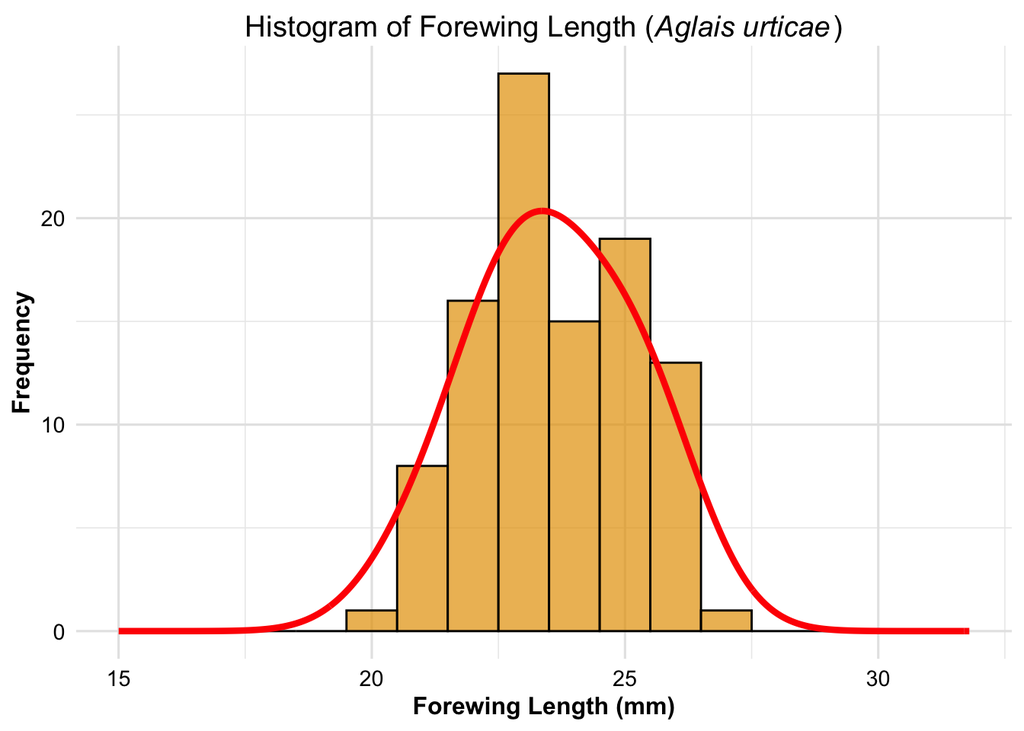

```r
ggplot(data_Aglais, aes(x = Forewing_length)) +
  geom_histogram(binwidth = 1, fill = "#E69F00", colour = "black", alpha = 0.7) +
  geom_density(aes(y = ..count.. * 1), colour = "red", size = 1.5, bw = 1) +
  xlim(c(min(data_Aglais$Forewing_length) - 5, max(data_Aglais$Forewing_length) + 5)) +
  labs(title = expression("Histogram of Forewing Length (" * italic("Aglais urticae") * ")"),
    x = "Forewing Length (mm)",
    y = "Frequency") +
  theme_bw() +
  theme_scientific()
```

1. Histogram of forewing length for *Aglais urticae*.

```r
shapiro.test(data_Aglais$Forewing_length)
```

```
##
##  Shapiro-Wilk normality test
##
## data:  data_Aglais$Forewing_length
## W = 0.98368, p-value = 0.2543
```

The histogram for *Aglais urticae* shows a unimodal, approximately symmetrical bell-shaped curve. The Shapiro-Wilk test returns a p-value greater than 0.05, suggesting no significant deviation from normality. Therefore, parametric tests are appropriate for this species.

### Histogram and Shapiro-Wilk Test for *Coenonympha pamphilus*

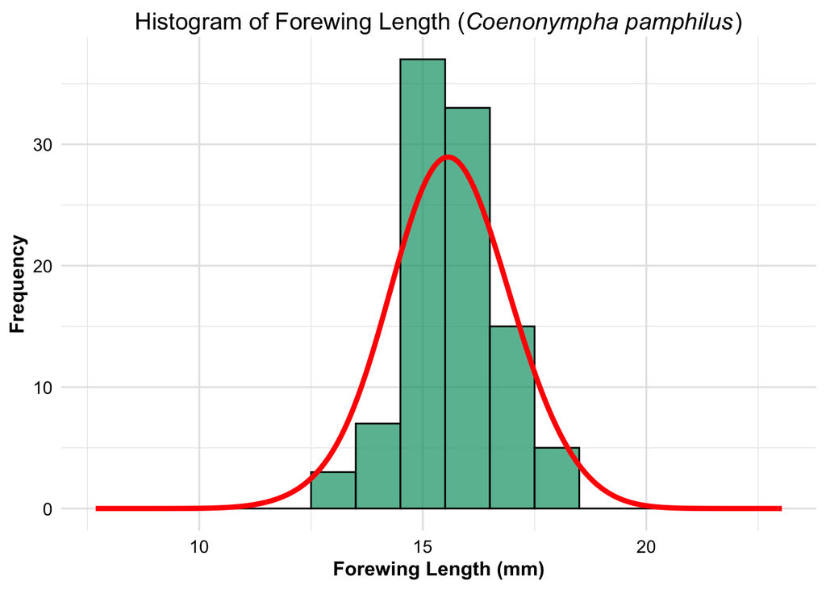

```r
ggplot(data_Coenonympha, aes(x = Forewing_length)) +
  geom_histogram(binwidth = 1, fill = "#009E73", colour = "black", alpha = 0.7) +
  geom_density(aes(y = ..count.. * 1), fill = "transparent", colour = "red", size = 1.5, bw = 1) +
  xlim(c(min(data_Coenonympha$Forewing_length) - 5, max(data_Coenonympha$Forewing_length) + 5)) +
  labs(title = expression("Histogram of Forewing Length (" * italic("Coenonympha pamphilus") * ")"),
    x = "Forewing Length (mm)",
    y = "Frequency") +
  theme_bw() +
  theme_scientific()
```

2. Histogram of forewing length for *Coenonympha pamphilus*.

```r
shapiro.test(data_Coenonympha$Forewing_length)
```

```
##
##  Shapiro-Wilk normality test
##
## data:  data_Coenonympha$Forewing_length
## W = 0.98064, p-value = 0.149
```

The distribution for *Coenonympha pamphilus* is similarly bell-shaped and passes the Shapiro-Wilk test for normality. This confirms that parametric analyses can also be used for this species.

# 3. Making Sampling Map

This code builds a detailed map showing butterfly sampling locations across the UK. It begins by importing spatial data for country and administrative boundaries, then defines three geographic regions (South, Midlands, North) based on latitude using custom functions. Each region is visualised with semi-transparent coloured polygons. Finally, butterfly sampling points are plotted and jittered slightly to reduce overlap, with points coloured by species.

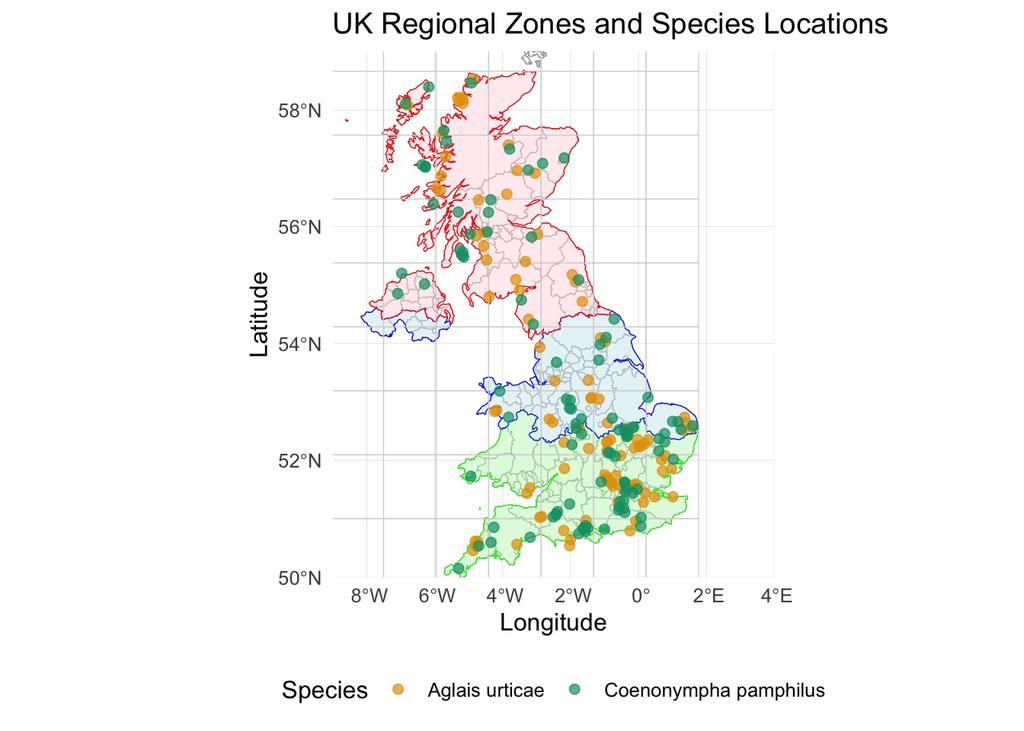

```r
# Load UK boundaries
uk <- ne_countries(scale = "large", country = "united kingdom", returnclass = "sf")
uk_regions <- ne_states(country = "united kingdom", returnclass = "sf")
uk_grid <- st_make_grid(uk, n = c(10, 10))

# Define region boundary functions
find_boundary_counties <- function(regions, boundary_lat) {
  region_centroids <- st_centroid(regions)
  region_coords <- st_coordinates(region_centroids)
  region_lats <- region_coords[,2]
  distance_to_boundary <- abs(region_lats - boundary_lat)
  closest_regions <- regions[distance_to_boundary < 1,]
  return(closest_regions)
}

create_zone_by_counties <- function(regions, min_lat, max_lat) {
  region_centroids <- st_centroid(regions)
  region_coords <- st_coordinates(region_centroids)
  in_zone <- region_coords[,2] >= min_lat & region_coords[,2] < max_lat
  zone_regions <- regions[in_zone,]
  if(length(zone_regions) > 0) {
    zone <- st_union(zone_regions)
  } else {
    zone <- NULL
  }
  return(zone)
}

# Define latitude-based regional zones
south_boundary <- 52.5
north_boundary <- 54.5
south <- create_zone_by_counties(uk_regions, 50, south_boundary)
midlands <- create_zone_by_counties(uk_regions, south_boundary, north_boundary)
north <- create_zone_by_counties(uk_regions, north_boundary, 59)

# Plot the map
ggplot() +
  geom_sf(data = uk, fill = "white", color = "black", size = 0.5) +
  geom_sf(data = uk_regions, fill = NA, color = "gray", size = 0.2) +
  geom_sf(data = south,    fill = "lightgreen", color = "green", alpha = 0.3) +
  geom_sf(data = midlands, fill = "lightblue",  color = "blue",  alpha = 0.3) +
  geom_sf(data = north,    fill = "pink",       color = "red",   alpha = 0.3) +
  geom_sf(data = uk_grid, fill = NA, color = "lightgray", size = 0.1) +
  geom_point(data = data,
             aes(x = Longitude, y = Latitude, color = Scientific_name),
             position = position_jitter(width = 0.1, height = 0.1),
             alpha = 0.7,
             size = 2) +
  scale_color_manual(values = c("#E69F00", "#009E73"), name = "Species") +
  coord_sf(xlim = c(-9, 4), ylim = c(50, 59), expand = FALSE) +
  theme_minimal(base_size = 12) +
  theme(panel.grid.major = element_line(color = "lightgray", size = 0.1),
        panel.grid.minor = element_blank(),
        legend.position = "bottom") +
  labs(title = "UK Regional Zones and Species Locations",
       x = "Longitude",
       y = "Latitude")
```

This map clearly shows butterfly sampling sites across the UK, coloured by species. The North, Midlands, and South regions are highlighted using coloured overlays derived from the centroids of administrative regions grouped by latitude. The use of `position_jitter` ensures overlapping points are visible, and the manually assigned colours improve species distinction.

# 4. Simple Linear Regression

We next modelled the relationship between morphological traits and environmental gradients.

## 4.1 Forewing Length ~ Mean Temperature

```r
model_au_temp <- lm(Forewing_length ~ avg_meantemp, data = data_Aglais)
model_cp_temp <- lm(Forewing_length ~ avg_meantemp, data = data_Coenonympha)
```

### Plot for *Aglais urticae*

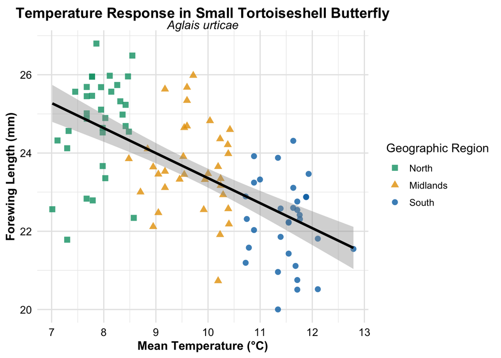

```r
ggplot(data_Aglais, aes(x = avg_meantemp, y = Forewing_length)) +
  geom_point(aes(color = region, shape = region), size = 2.5, alpha = 0.8) +
  geom_smooth(aes(group = 1), method = "lm", se = TRUE, linewidth = 1.2, color = "black") +
  scale_color_manual(name = "Geographic Region",
                     breaks = c("North", "Midlands", "South"),
                     values = c("North" = "#009E73", "Midlands" = "#E69F00", "South" = "#0072B2")) +
  scale_shape_manual(name = "Geographic Region",
                     breaks = c("North", "Midlands", "South"),
                     values = c("North" = 15, "Midlands" = 17, "South" = 16)) +
  labs(title = "Temperature Response in Small Tortoiseshell Butterfly",
       subtitle = "Aglais urticae",
       x = "Mean Temperature (°C)",
       y = "Forewing Length (mm)") +
  theme_scientific()
```

1. Forewing length vs. mean temperature for *Aglais urticae*.

This regression model shows a clear negative relationship between temperature and forewing length in *Aglais urticae*. Higher temperatures are associated with shorter wings, indicating a strong thermal sensitivity.

### Plot for *Coenonympha pamphilus*

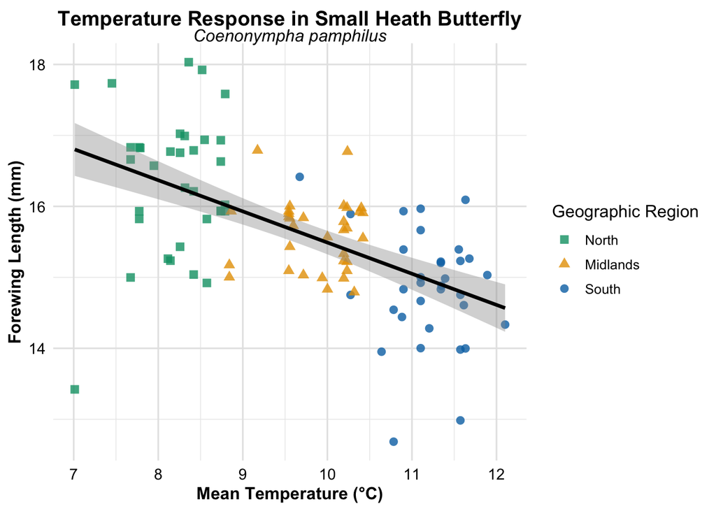

```r
ggplot(data_Coenonympha, aes(x = avg_meantemp, y = Forewing_length)) +
  geom_point(aes(color = region, shape = region), size = 2.5, alpha = 0.8) +
  geom_smooth(aes(group = 1), method = "lm", se = TRUE, linewidth = 1.2, color = "black") +
  scale_color_manual(name = "Geographic Region",
                     breaks = c("North", "Midlands", "South"),
                     values = c("North" = "#009E73", "Midlands" = "#E69F00", "South" = "#0072B2")) +
  scale_shape_manual(name = "Geographic Region",
                     breaks = c("North", "Midlands", "South"),
                     values = c("North" = 15, "Midlands" = 17, "South" = 16)) +
  labs(title = "Temperature Response in Small Heath Butterfly",
       subtitle = "Coenonympha pamphilus",
       x = "Mean Temperature (°C)",
       y = "Forewing Length (mm)") +
  theme_scientific()
```

2. Forewing length vs. mean temperature for *Coenonympha pamphilus*.

A similar negative trend is observed for *Coenonympha pamphilus*, but the relationship is weaker, indicating this specialist species may be less responsive to mean temperature.

## 4.2 Forewing Length ~ Latitude

```r
model_au_lat <- lm(Forewing_length ~ Latitude, data = data_Aglais)
model_cp_lat <- lm(Forewing_length ~ Latitude, data = data_Coenonympha)
```

### Plot for *Aglais urticae*

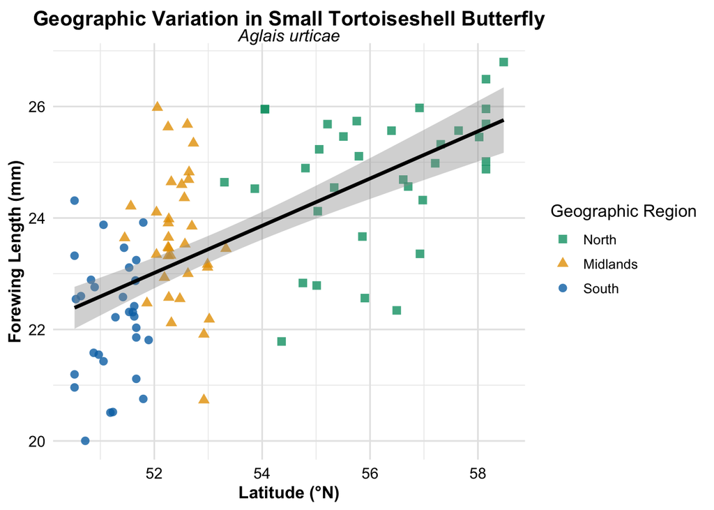

```r
ggplot(data_Aglais, aes(x = Latitude, y = Forewing_length)) +
  geom_point(aes(color = region, shape = region), size = 2.5, alpha = 0.8) +
  geom_smooth(aes(group = 1), method = "lm", se = TRUE, linewidth = 1.2, color = "black") +
  scale_color_manual(name = "Geographic Region",
    breaks = c("North", "Midlands", "South"),
    values = c("North" = "#009E73", "Midlands" = "#E69F00", "South" = "#0072B2")) +
  scale_shape_manual(name = "Geographic Region",
    breaks = c("North", "Midlands", "South"),
    values = c("North" = 15, "Midlands" = 17, "South" = 16)) +
  labs(title = "Geographic Variation in Small Tortoiseshell Butterfly",
    subtitle = "Aglais urticae",
    x = "Latitude (°N)",
    y = "Forewing Length (mm)") +
  theme_scientific()
```

1. Forewing length vs. latitude for *Aglais urticae*.

Forewing length increases with latitude in *Aglais urticae*, consistent with Bergmann’s Rule and larger body sizes in colder climates.

### Plot for *Coenonympha pamphilus*

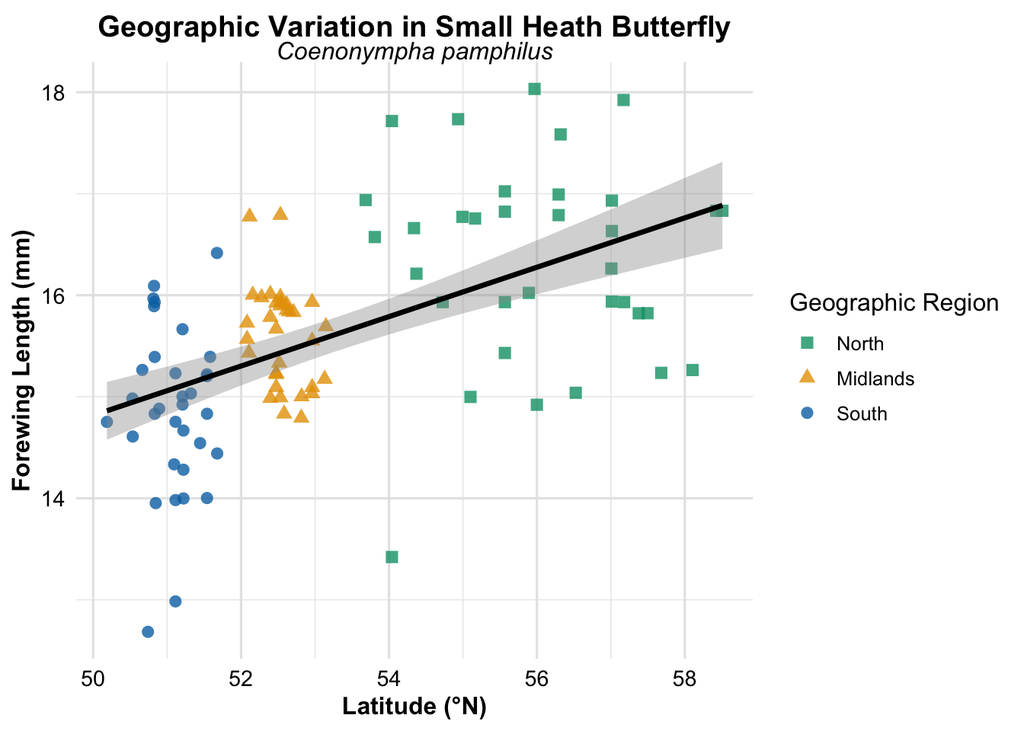

```r
ggplot(data_Coenonympha, aes(x = Latitude, y = Forewing_length)) +
  geom_point(aes(color = region, shape = region), size = 2.5, alpha = 0.8) +
  geom_smooth(aes(group = 1), method = "lm", se = TRUE, linewidth = 1.2, color = "black") +
  scale_color_manual(name = "Geographic Region",
                     breaks = c("North", "Midlands", "South"),
                     values = c("North" = "#009E73", "Midlands" = "#E69F00", "South" = "#0072B2")) +
  scale_shape_manual(name = "Geographic Region",
                     breaks = c("North", "Midlands", "South"),
                     values = c("North" = 15, "Midlands" = 17, "South" = 16)) +
  labs(title = "Geographic Variation in Small Heath Butterfly",
       subtitle = "Coenonympha pamphilus",
       x = "Latitude (°N)",
       y = "Forewing Length (mm)") +
  theme_scientific()
```

2. Forewing length vs. latitude for *Coenonympha pamphilus*.

Although a positive relationship is also seen in *C. pamphilus*, the model fit is weaker, again suggesting more variable or buffered morphology.

# 5. ANOVA for Regional Differences

This section tests whether forewing size differs across regions (North, Midlands, South).

```r
# Subset by species
species1_data <- filter(data, Scientific_name == "Aglais urticae")
species2_data <- filter(data, Scientific_name == "Coenonympha pamphilus")

# Run one-way ANOVA
anova_au <- aov(Forewing_length ~ region, data = species1_data)
anova_cp <- aov(Forewing_length ~ region, data = species2_data)

# Post hoc tests
posthoc_au <- emmeans(anova_au, pairwise ~ region)
posthoc_cp <- emmeans(anova_cp, pairwise ~ region)

# Show results
summary(anova_au)
```

```
##             Df Sum Sq Mean Sq F value  Pr(>F)
## region       2  107.7   53.87   40.66 1.5e-13 ***
## Residuals   97  128.5    1.33
## ---
## Signif. codes:  0 '***' 0.001 '**' 0.01 '*' 0.05 '.' 0.1 ' ' 1
```

```r
summary(anova_cp)
```

```
##             Df Sum Sq Mean Sq F value   Pr(>F)
## region       2  37.30  18.649   29.23 1.16e-10 ***
## Residuals   97  61.89   0.638
## ---
## Signif. codes:  0 '***' 0.001 '**' 0.01 '*' 0.05 '.' 0.1 ' ' 1
```

```r
posthoc_au
```

```
## $emmeans
##  region   emmean    SE df lower.CL upper.CL
##  Midlands   23.6 0.197 97     23.2     24.0
##  North      24.8 0.197 97     24.4     25.2
##  South      22.2 0.203 97     21.8     22.6
##
## Confidence level used: 0.95
##
## $contrasts
##  contrast         estimate    SE df t.ratio p.value
##  Midlands - North    -1.14 0.279 97  -4.075  0.0003
##  Midlands - South     1.42 0.284 97   4.995  <.0001
##  North - South        2.55 0.284 97   9.008  <.0001
##
## P value adjustment: tukey method for comparing a family of 3 estimates
```

```r
posthoc_cp
```

```
## $emmeans
##  region   emmean    SE df lower.CL upper.CL
##  Midlands   15.6 0.139 97     15.3     15.9
##  North      16.3 0.137 97     16.1     16.6
##  South      14.9 0.139 97     14.6     15.1
##
## Confidence level used: 0.95
##
## $contrasts
##  contrast         estimate    SE df t.ratio p.value
##  Midlands - North   -0.743 0.195 97  -3.807  0.0007
##  Midlands - South    0.749 0.197 97   3.811  0.0007
##  North - South       1.492 0.195 97   7.646  <.0001
##
## P value adjustment: tukey method for comparing a family of 3 estimates
```

The ANOVA results show that forewing length differs significantly across UK regions in both species. For *Aglais urticae*, the ANOVA returned a highly significant F value, indicating strong between-group variance relative to within-group variance. Post hoc Tukey tests confirmed that individuals from the North had significantly longer wings than those from the Midlands and South, and all pairwise regional comparisons were statistically significant.

Similarly, for *Coenonympha pamphilus*, the ANOVA also indicated significant regional structuring, though with a slightly lower effect magnitude. Post hoc comparisons again revealed significant differences between all regions, with northern individuals having the longest wings and southern individuals the shortest. These findings support a latitudinal gradient in wing size, consistent with ecological principles such as Bergmann’s Rule.

### Regional Mean Comparison Plot

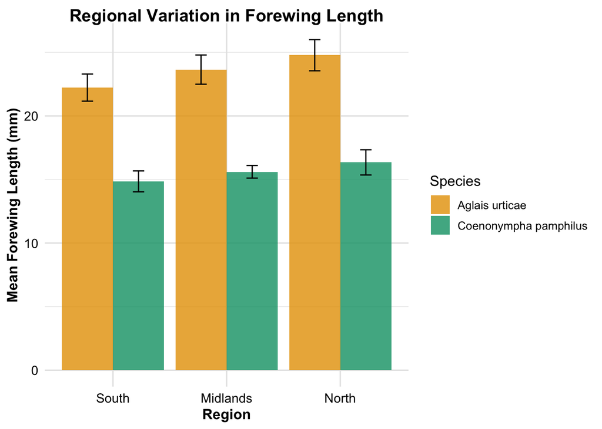

Figure 6. Regional mean forewing length with standard deviation bars.

```r
regional_summary <- data %>%
  group_by(Scientific_name, region) %>%
  summarise(mean_length = mean(Forewing_length),
            sd_length = sd(Forewing_length), .groups = 'drop')

regional_summary$region <- factor(regional_summary$region, levels = c("South", "Midlands", "North"))

ggplot(regional_summary, aes(x = region, y = mean_length, fill = Scientific_name)) +
  geom_bar(stat = "identity", position = "dodge", alpha = 0.8) +
  geom_errorbar(aes(ymin = mean_length - sd_length,
                    ymax = mean_length + sd_length),
                position = position_dodge(0.9),
                width = 0.2) +
  labs(title = "Regional Variation in Forewing Length",
    x = "Region",
    y = "Mean Forewing Length (mm)") +
  theme_scientific() +
  scale_fill_manual(values = c("#E69F00", "#009E73"),
    name = "Species",
    labels = unique(data$Scientific_name))
```

Mean forewing size increases consistently from South to North in both species. One-way ANOVA and Tukey’s post hoc tests confirm significant differences across all regions.

# 6. Random Forest Models and Variable Importance

We used Random Forest regression to assess the relative importance of climate variables in predicting wing length.

```r
create_rf_model <- function(data) {
  randomForest(Forewing_length ~ avg_tmax + avg_tmin + avg_meantemp + avg_rain + avg_sun + region,
               data = data, ntree = 1000, importance = TRUE)
}

rf_model1 <- create_rf_model(species1_data)
rf_model2 <- create_rf_model(species2_data)

importance_df <- data.frame(
  Variable = rownames(importance(rf_model1)),
  Species1 = importance(rf_model1)[, "%IncMSE"],
  Species2 = importance(rf_model2)[, "%IncMSE"])
importance_melt <- reshape2::melt(importance_df, id.vars = "Variable")
```

### Variable Importance Comparison

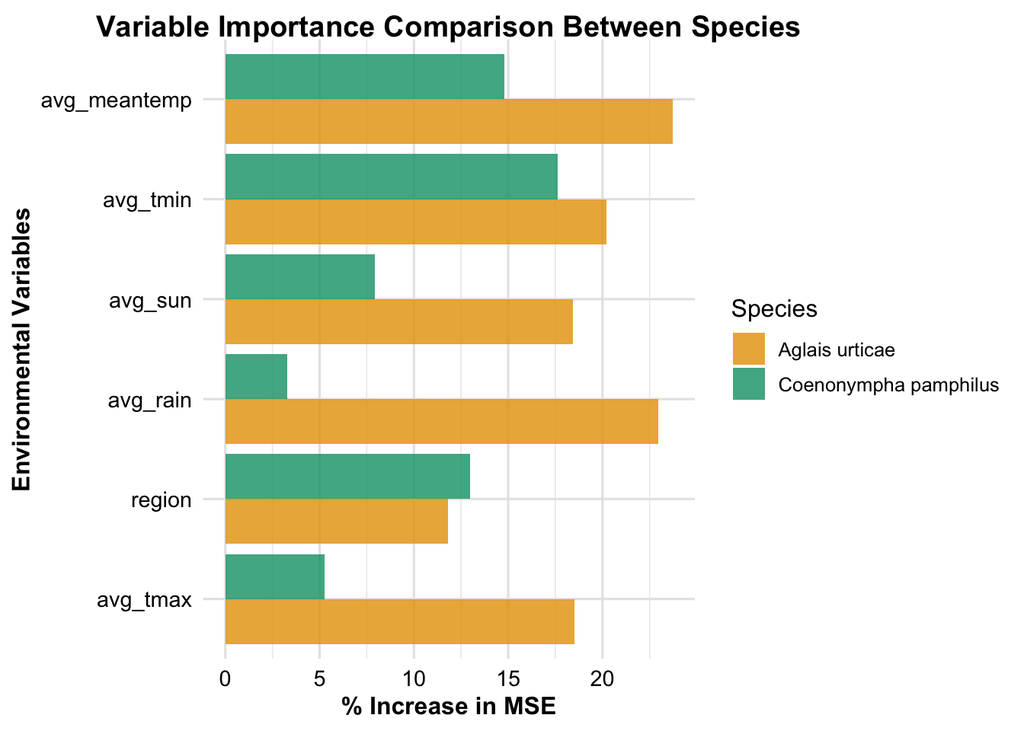

Figure 7. Random Forest variable importance for both butterfly species.

```r
ggplot(importance_melt, aes(x = reorder(Variable, value), y = value, fill = variable)) +
  geom_bar(stat = "identity", position = "dodge", alpha = 0.8) +
  coord_flip() +
  labs(title = "Variable Importance Comparison Between Species",
    x = "Environmental Variables",
    y = "% Increase in MSE") +
  theme_scientific() +
  scale_fill_manual(values = c("#E69F00", "#009E73"),
    name = "Species",
    labels = unique(data$Scientific_name))
```

*Aglais urticae* showed strong importance across all temperature variables, with mean temperature contributing the most. In contrast, *C. pamphilus* showed a narrower set of key predictors, with minimum temperature dominating.

### Model Performance Metrics

```r
rmse1 <- sqrt(mean((species1_data$Forewing_length - predict(rf_model1))^2))
rmse2 <- sqrt(mean((species2_data$Forewing_length - predict(rf_model2))^2))

cat("Species 1 R-squared:", round(rf_model1$rsq[length(rf_model1$rsq)] * 100, 2), "%\n")
```

```
## Species 1 R-squared: 39.93 %
```

```r
cat("Species 2 R-squared:", round(rf_model2$rsq[length(rf_model2$rsq)] * 100, 2), "%\n")
```

```
## Species 2 R-squared: 6.38 %
```

```r
cat("Species 1 RMSE:", round(rmse1, 3), "mm\n")
```

```
## Species 1 RMSE: 1.191 mm
```

```r
cat("Species 2 RMSE:", round(rmse2, 3), "mm\n")
```

```
## Species 2 RMSE: 0.964 mm
```

# Conclusion

This analysis revealed clear and biologically meaningful patterns in butterfly wing morphology across the United Kingdom, aligning with established ecological theories while also uncovering species-specific nuances. Both *Aglais urticae* (a generalist) and *Coenonympha pamphilus* (a specialist) exhibited significant morphological adaptation to environmental gradients, with forewing length increasing at higher latitudes and decreasing with higher mean temperatures. These trends are broadly consistent with **Bergmann’s Rule**, which posits that organisms in colder climates tend to be larger-bodied, potentially for thermoregulatory efficiency. The results also suggest limited support for **Allen’s Rule**, although this study did not directly assess limb-to-body size ratios.

Importantly, the Random Forest results suggest that **climatic variables alone do not fully explain morphological variation**, especially for specialist species. This highlights a key limitation and an opportunity for future research. Additional factors such as host plant availability, photoperiod, genetic structure, and microhabitat use may also play significant roles in shaping trait distributions. Furthermore, while wing length is a practical and ecologically relevant metric, incorporating other morphological dimensions (e.g. wing shape, thorax size) could offer a more complete picture of adaptive responses.

Future research should also explore **longitudinal datasets** to distinguish between phenotypic plasticity and evolutionary change, and consider integrating **genomic data** to identify heritable components of morphological traits. Comparative studies across more species with varying ecological strategies could help generalise the observed patterns and further test the predictive limits of ecogeographical rules.

Overall, this study demonstrates the value of combining museum specimen data, spatial environmental datasets, and both statistical and machine learning models to understand the drivers of morphological adaptation. It highlights the complexity of trait-environment interactions and underscores the need for multi-factor, species-specific approaches when predicting biological responses to environmental change.

Thanks for reading :)